# Descrição de características estéticas e da estrutura de playlists do Spotify

Guilherme Bovi Ambrosano  
Dora Yovana Barrios Leal

## Introdução

## Importância da música

- Processar emoções e compreender o mundo (Dale, 2017; Hernandez-Ruiz et al., 2020; Jankélévitch, 2024; Lesiuk, 2005)
- Moldar identidades (Koskinen, 2021; Machado, 2024)
- **As características estéticas são importantes** (Baudrillard, 1991; Jankélévitch, 2024; Pio X, 1903)

## Gêneros musicais

- Definem uma estética e delimitam identidades (De Albuquerque Maranhão, 2025; DjeDje, 1989; Ingalls et al., 2016; Koskinen, 2021; Lopes, 2007, 2009; Machado, 2024)
- Gêneros musicais **interagem** uns com os outros e com a sociedade (Félix, 2015; Fernández e Vila, 2013; Grossberg, 1986; Mueller, 2016; Rieger, 2017)
- Ecologia do simbólico (Herschmann e Lacombe, 2024; Park e Park, 2025; Solares, 2018; Van Venrooij, 2015)
- Sampling e remixagem (Buzato et al., 2013; Park e Park, 2025)

## A música na Era da Indústria Cultural

- Identidade vs. padronização (Adorno e Horkheimer, 1985; Baudrillard, 1991)
- Ouvintes formam identidades com os gêneros musicais, **mesmo com a influência da indústria** (Buzato et al., 2013; Hall, 2007; Jenkins, 2022)

## Playlists do Spotify

- Spotify foi criado para facilitar o consumo de música e contornar a pirataria
- A plataforma permite a criação de **playlists**, que passaram a ser uma forma importante de consumo de músicas (Stanisljevic, 2020)
- Playlists podem representar gêneros musicais, sensações ou atividades (McDonald et al., 2025; Siles et al., 2019)
- **Recomendação algorítmica** de músicas (Deldjoo et al., 2024; Wang e Caverlee, 2020; Wu et al., 2024)

## Como medir a similaridade ou diferença entre músicas?

- Características quantitativas (Aucouturier e Pachet, 2003; Li e Ogihara, 2005; Tzanetakis e Cook, 2002)
- Variáveis do The Echo Nest (Al-Beitawi et al., 2020; Pelchat e Gelowitz, 2020; Riyadi et al., 2024)
- Tags do Last.fm (Castillo et al., 2024)
- Análise da faixa de áudio (Elbir e Aydin, 2020)

## Objetivos

- Identificar padrões em músicas de playlists

## Metodologia ou Material e Métodos

## Base de dados

- Quatro conjuntos de dados do Kaggle
  - Kaggle e MaharshiPandya (2026)
  - Kaggle e Tomigelo (2026)
  - Kaggle e Rodolfo Figueroa (2026)
  - Kaggle e Viktoriia Shkurenko (2026)
- 1.631.083 faixas de música
- 6.016 playlists
- 472 gêneros musicais ou queries

## Variáveis analisadas

- Danceability (0 a 1)
- Energy (0 a 1)
- Speechiness (0 a 1)
- Acousticness (0 a 1)
- Instrumentalness (0 a 1)
- Liveness (0 a 1)
- Valence (0 a 1)
- Loudness (-60 dB a 0 dB)
- Duration (ms)
- Tempo (bpm)

## Análise estatística

- Redução de dimensionalidade
  - Análise de componentes principais
  - Análise discriminante linear
  - Análise canônica discriminante
- Formação de supergrupos
  - Agrupamento hierárquico aglomerativo
  - K-means
- Predição dos supergrupos
  - K-nearest neighbors
  - Random forest
  - Support vector machine

## Resultados e discussão

## Autoria das playlists

- Inicialmente, utilizou-se os dados de Kaggle e Viktoriia Shkurenko (2026) para comparar playlists de autoria de usuários e de autoria do Spotify
- Segundo Spotify for Artists (2018):
  - Curadoria algorítmica
  - Curadas pelos editores do Spotify
- Por outro lado, as playlists de usuários sofrem influência da recomendação algorítmica (Kamehkhosh et al., 2020; Stanisljevic, 2020)

## Correlações

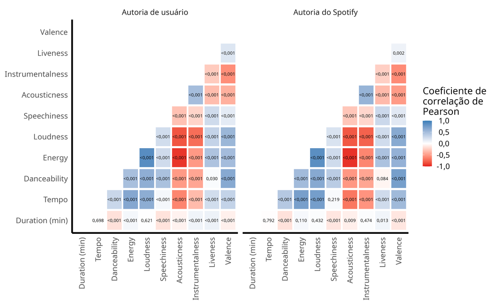

## Correlações

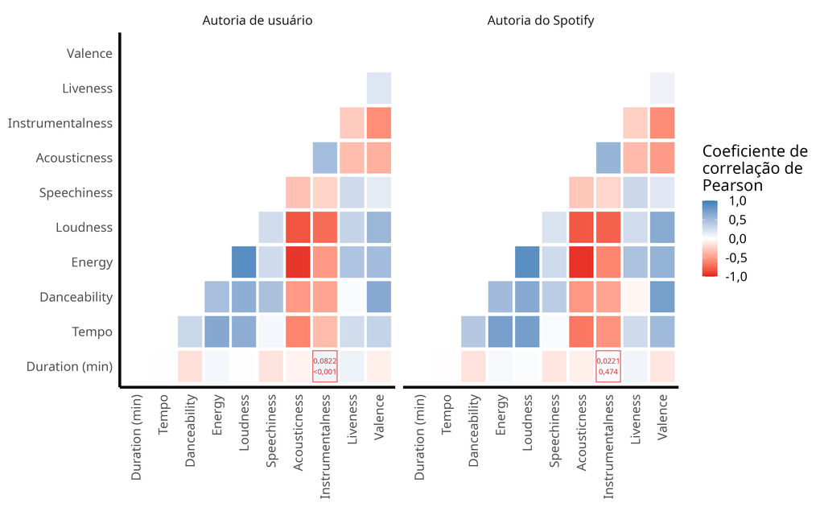

## Correlações

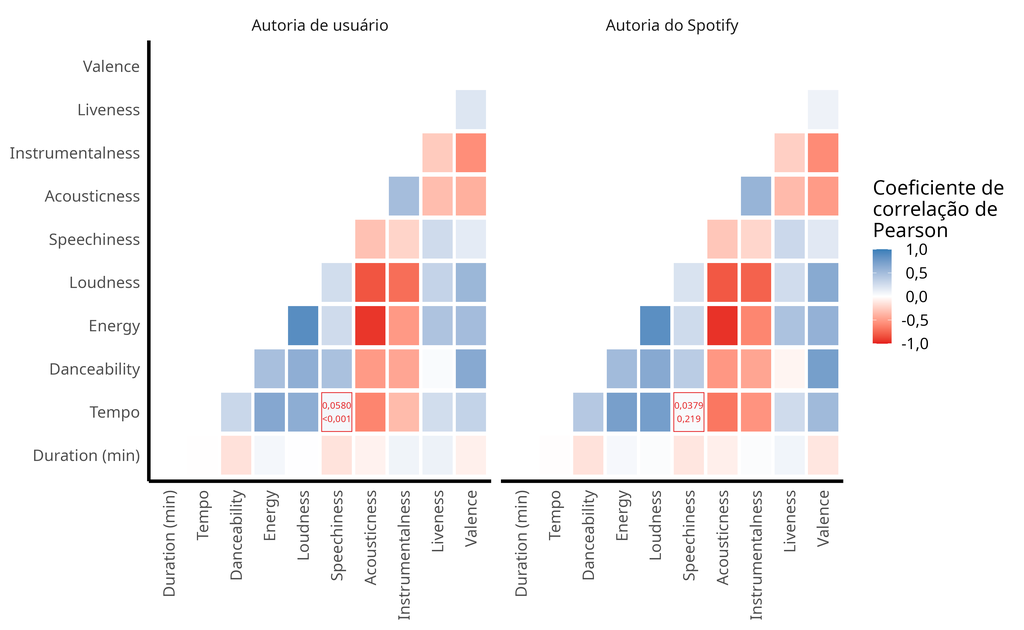

## Análise canônica discriminante

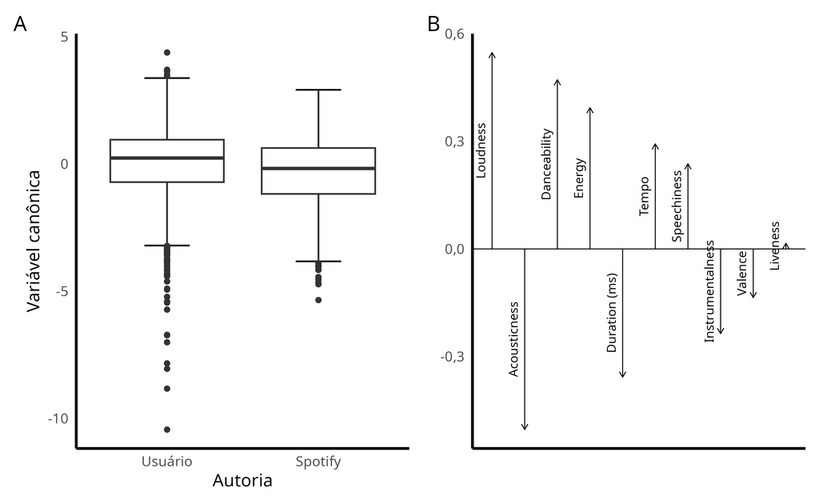

## Autoria das playlists

- Playlists de usuários apresentaram correlações muito fracas e positivas entre Instrumentalness e duração (r=0,0822) e entre Speechiness e andamento (r=0,0580), o que não apareceu em playlists do Spotify
- Playlists do Spotify apresentam mais Acousticness e Instrumentalness e menos Loudness, Tempo, Energy e Danceability do que playlists de usuários, com tamanho do efeito pequeno (η<sub>p</sub><sup>2</sup>=0,0397)
- Recomendações algorítmicas priorizam relações que não são intuitivamente observadas pelos humanos (Deldjoo et al., 2024; Wang e Caverlee, 2020; Wu et al., 2024)
- Isso pode afetar até mesmo playlists de autoria de usuários (Kamehkhosh et al., 2020)

## Grupos de playlists

- Análise discriminante para classificar queries (Kaggle e Viktoriia Shkurenko, 2026) ou gêneros musicais (Kaggle e MaharshiPandya, 2026)
- Agrupamento hierárquico aglomerativo com as quatro primeiras variáveis discriminantes

## Agrupamento

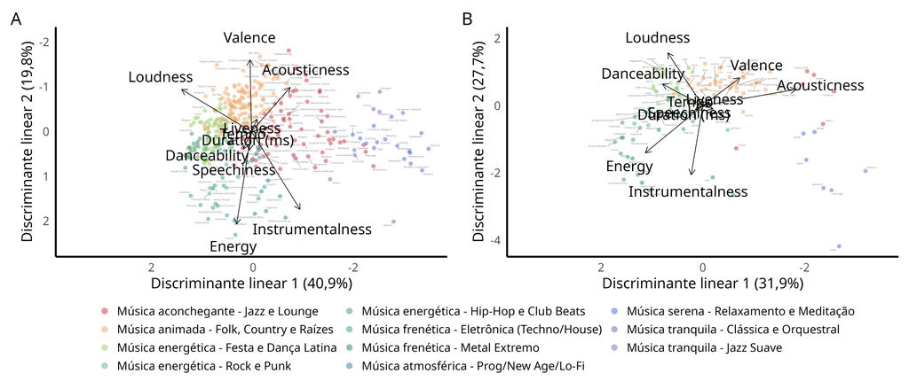

## Acurácias dos modelos de machine learning

| Supergrupo | KNN | SVM | RF |
| --- | --- | --- | --- |
| Geral | 89,93% (83,68% ‒ 94,38%) | 43,17% (34,80% ‒ 51,83%) | 82,01% (74,61% ‒ 88,01%) |
| Música aconchegante | 97,06% | 85,37% | 79,89% |
| Música animada | 96,22% | 69,65% | 89,03% |
| Música energética | 94,58% | 50,00% | 91,68% |
| Música frenética | 98,88% | 85,90% | 89,63% |
| Música atmosférica | 50,00% | 48,91% | 98,54% |
| Música tranquila | 71,05% | 98,11% | 77,06% |
| Música serena | 98,50% | 50,00% | 98,87% |

## Supergêneros

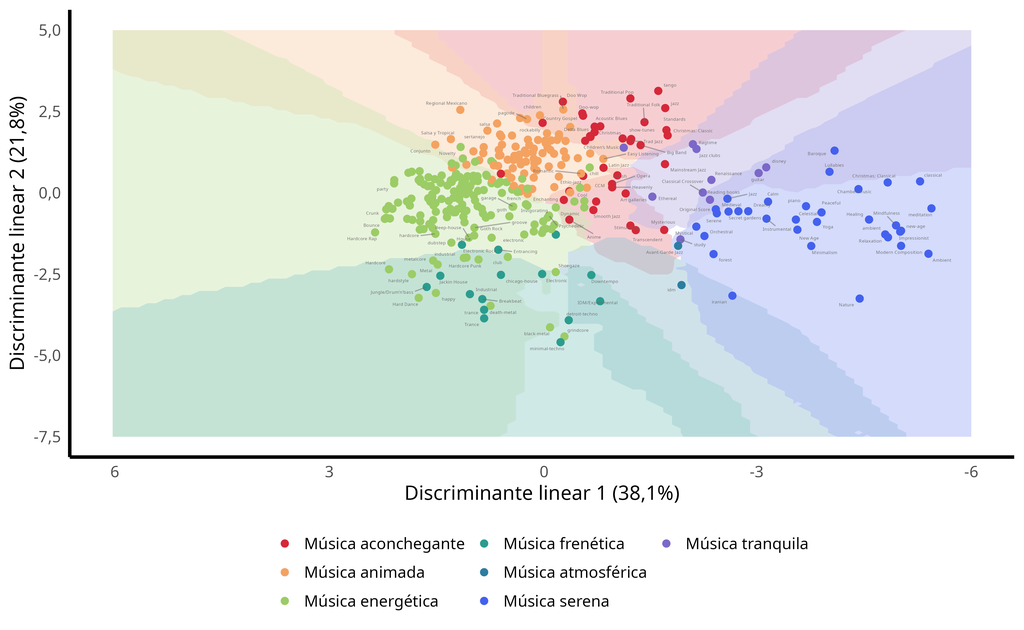

## Composição de playlists

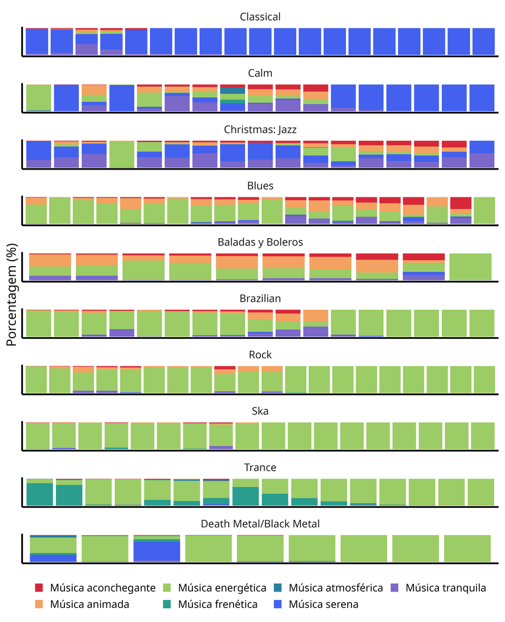

## Exemplos

Alguns exemplos de playlists:

[interactive chart not shown]

[interactive chart not shown]

**Todas as músicas**

[interactive chart not shown]

## Verifique sua própria playlist

- Disponível em: https://tcc-app-2icb.onrender.com/

[interactive chart not shown]

## Associação com a autoria

[output not shown]

## Resultados

- Há uma sobreposição grande entre os supergrupos no espaço multivariado
- Um gênero musical é acompanhado por relações sociais complexas (Aucouturier e Pachet, 2003; Li e Ogihara, 2005; Tzanetakis e Cook, 2002)
- Os gêneros musicais e as playlists interagem em uma ecologia do simbólico (Koskinen, 2021; Scarratt et al., 2023; Van Venrooij, 2015)
- Muitas das características percebidas por um ouvinte não estão presentes nas variáveis estudadas (Sturm, 2013)
- O uso das variáveis do The Echo Nest levou a algumas classificações equivocadas, demonstrando a dificuldade em se trabalhar com essas variáveis quantitativas (Castillo et al., 2024; Sturm, 2013)

## Resultados

- O espaço formado pela análise linear discriminante levou a maiores acurácias; os algoritmos KNN e RF foram os melhores para classificar os supergêneros, enquanto o SVM foi o pior
- Os grupos de playlists analisados separam-se principalmente quanto ao nível de energia contraposto à qualidade acústica
- Playlists do Spotify apresentam músicas mais tranquilas, enquanto playlists de usuários apresentam mais músicas energéticas
- Playlists classificadas com os mesmos queries apresentaram variação quanto às porcentagens de músicas de cada supergênero, evidência da diferença entre estilos curatoriais (Hernandez-Ruiz et al., 2020; Scarratt et al., 2023; Wang e Caverlee, 2020)
- Esforços cada vez maiores para proteger dados e restringir APIs: APIcalypse (Chen et al., 2024; Mimizuka et al., 2025; Trezza, 2023)
- Outros meios de clasificar os gêneros musicais incluem tags do Last.fm (Castillo et al., 2024) e as faixas de áudio (Elbir e Aydin, 2020)

## Considerações finais

## Considerações finais

- É possível agrupar músicas semelhantes usando as variáveis do The Echo Nest
  - Sete supergêneros: música serena, tranquila, animada, aconchegante, energética, frenética e atmosférica
- Muitas músicas tranquilas/serenas são inseridas em playlists de autoria do Spotify, havendo uma chance menor de ouvintes criarem playlists desses supergêneros
- Variáveis do The Echo Nest são, ao mesmo tempo, redundantes e insuficientes
  - A variação dos dados pôde ser explicada por apenas quatro componentes principais
  - Elementos que não foram capturados incluem o uso de determinados instrumentos e a presença de certas palavras nas letras das músicas
  - Modelos mais complexos que analisassem as faixas de áudio ou tags do Last.fm poderiam capturar parte da informação que não pôde ser analisada aqui
- É preciso que sejam desenvolvidos métodos padronizados para estudar a percepção e o consumo de música
- Iniciativas que disponibilizem dados para a pesquisa

## Referências

Adorno, T.W.; Horkheimer, M. 1985. Dialética do esclarecimento. ISBN 9788571104143.

Al-Beitawi, Z.; Salehan, M.; Zhang, S. 2020. What makes a song trend? Cluster analysis of musical attributes for Spotify top trending songs. Journal of Marketing Development and Competitiveness 14(3): 79–91. Disponível em: <https://doi.org/10.33423/jmdc.v14i3.3065>.

Aucouturier, J.-J.; Pachet, F. 2003. Representing musical genre: A state of the art. Journal of new music research 32(1): 83–93. Disponível em: <https://doi.org/10.1076/jnmr.32.1.83.16801>.

Baudrillard, J. 1991. Simulacros e simulação. ISBN 9789727081417.

Buzato, M.E.K.; Silva, D.P. da; Coser, D.S.; Barros, N.N. de; Sachs, R.S. 2013. Remix, mashup, paródia e companhia: por uma taxonomia multidimensional da transtextualidade na cultura digital. Revista Brasileira de Linguı́stica Aplicada 13(4): 1191–1221. Disponível em: <https://doi.org/10.1590/S1984-63982013000400011 >.

Castillo, J.R.; Flores, M.J.; Leray, P. 2024. Predicting spotify audio features from Last. fm tags. Multimedia Tools and Applications 83(16): 48311–48330. Disponível em: <https://doi.org/10.1007/s11042-023-17160-5>.

Chen, Y.; Sherren, K.; Lee, K.Y.; McCay-Peet, L.; Xue, S.; Smit, M. 2024. From theory to practice: insights and hurdles in collecting social media data for social science research. Frontiers in Big Data 7(1): e1379921. Disponível em: <https://doi.org/10.3389/fdata.2024.1379921>.

Dale, H. 2017. The last music on earth: Prehistory and the function of music in’The Road’. Fields: journal of Huddersfield student research 3(1): 3–11. Disponível em: <https://doi.org/10.2307/2707753>.

De Albuquerque Maranhão, R. 2025. A Complexidade da Apologia ao Crime no Funk/Trap Carioca: Uma Análise da Liberdade Artística Vs. Controle Social. ARACÊ 7(7): 37319–37333. Disponível em: <https://doi.org/10.56238/arev7n7-122>.

Deldjoo, Y.; Schedl, M.; Knees, P. 2024. Content-driven music recommendation: Evolution, state of the art, and challenges. Computer Science Review 51(1): e100618. Disponível em: <https://doi.org/10.1016/j.cosrev.2024.100618>.

DjeDje, J. 1989. Gospel Music in the Los Angeles Black Community: A Historical Overview. Black Music Research Journal 9(1): 35–79. Disponível em: <https://doi.org/10.2307/779432>.

Elbir, A.; Aydin, N. 2020. Music genre classification and music recommendation by using deep learning. Electronics Letters 56(12): 627–629. Disponível em: <https://doi.org/10.1049/el.2019.4202>.

Félix, J.P. 2015. Folk or Fake: The Notion of Authenticity in Portuguese Fado. Tese de Doutorado em Música. University of Leeds, Leeds, GB. Disponível em: <https://etheses.whiterose.ac.uk/id/eprint/9600/>. Acesso em: 12 mar. 2026.

Fernández, H.; Vila, P. 2013. Cumbia! Scenes of a Migrant Latin American Music Genre. Disponível em: <https://doi.org/10.2307/j.ctv11314nd>.

Grossberg, L. 1986. Is there rock after punk? Critical Studies in Mass Communication 3(1): 50–74. Disponível em: <https://doi.org/10.1080/15295038609366629>.

Hall, S. 2007. Encoding/Decoding in TV Discourse. v. 2 p. 402–414. *In*: Gray, A.; Campbell, J.; Erickson, M.; Hanson, S.; Wood, H. (orgs.). CCCS selected working papers. Editora Routledge, Londres, GB. ISBN 9780415324410.

Hernandez-Ruiz, E.; James, B.; Noll, J.; Chrysikou, E.G. 2020. What makes music relaxing? An investigation into musical elements. Psychology of Music 48(3): 327–343. Disponível em: <https://doi.org/10.1177/0305735618798027>.

Herschmann, M.; Lacombe, F. 2024. Pesquisando ecotranssistemas musicais-midiáticos na cidade do Rio de Janeiro. Galáxia 49(1): e63891. Disponível em: <https://revistas.pucsp.br/index.php/galaxia/article/view/63981>. Acesso em: 28 fev. 2026.

Ingalls, M.; Landau, C.; Wagner, T. (Orgs.). 2016. Christian congregational music: Performance, identity and experience. ISBN 9781315571850.

Jankélévitch, V. 2024. Music and the Ineffable. ISBN 9780691090474.

Jenkins, H. 2022. Cultura da convergência. ISBN 9786586064841.

Kaggle; MaharshiPandya. 2026. Spotify Tracks Dataset. DOI 10.34740/KAGGLE/DSV/4372070. Disponível em: <https://www.kaggle.com/datasets/maharshipandya/-spotify-tracks-dataset>. Acesso em: 12 mar. 2026.

Kaggle; Rodolfo Figueroa. 2026. Spotify 1.2M+ Songs. Disponível em: <https://www.kaggle.com/datasets/rodolfofigueroa/spotify-12m-songs>. Acesso em: 12 mar. 2026.

Kaggle; Tomigelo. 2026. Spotify Audio Features. Disponível em: <https://www.kaggle.com/datasets/tomigelo/spotify-audio-features>. Acesso em: 12 mar. 2026.

Kaggle; Viktoriia Shkurenko. 2026. 6K Spotify Playlists. Disponível em: <https://www.kaggle.com/datasets/viktoriiashkurenko/278k-spotify-songs>. Acesso em: 12 mar. 2026.

Kamehkhosh, I.; Bonnin, G.; Jannach, D. 2020. Effects of recommendations on the playlist creation behavior of users. User Modeling and User-Adapted Interaction 30(2): 285–322. Disponível em: <https://doi.org/10.1007/s11257-019-09237-4>.

Koskinen, H.J. 2021. Recognition, Identity, and Authenticity in the Blues. Itinerari 1(LX): 289–306. Disponível em: <https://doi.org/10.7413/2036-9484046>.

Lesiuk, T. 2005. The effect of music listening on work performance. Psychology of music 33(2): 173–191. Disponível em: <https://doi.org/10.1177/0305735605050650>.

Li, T.; Ogihara, M. 2005. Music genre classification with taxonomy. *In*: International Conference on Acoustics, Speech, and Signal Processing (ICASSP), 2005, Philadelphia, PA, US. Anais... Disponível em: <https://doi.org/10.1109/ICASSP.2005.1416274>.

Lopes, A.C. 2007. A Construção da identidade juvenil no funk carioca. Revista do SETA 1(1): Disponível em: <https://revistas.iel.unicamp.br/index.php/seta/article/view/241>. Acesso em: 28 fev. 2026.

Lopes, A.C. 2009. A favela tem nome próprio: a (re) significação do local na linguagem do funk carioca. Revista Brasileira de Linguı́stica Aplicada 9(2): 369–390. Disponível em: <https://doi.org/10.1590/S1984-63982009000200002>.

Machado, M.K. 2024. Avisa o dono da Lacoste que nós tá milionário: o papel do trap e do funk ostentação na construção da identidade lacosteira. Monografia de Bacharelado em Publicidade e Propaganda. Pontifícia Universidade Católica do Rio Grande do Sul, Porto Alegre, RS, BR. Disponível em: <https://repositorio.pucrs.br/dspace/bitstream/10923/27315/1/2024_2_MANUELA_KVIETINSKI_MACHADO_TCC.pdf>. Acesso em: 28 fev. 2026.

McDonald, C.; Foster, A.E.; Rafferty, P. 2025. Playlists and genre: the role of music genre in Spotify’s playlists. Journal of Documentation 81(1): 1–23. Disponível em: <https://doi.org/10.1108/JD-08-2023-0152>.

Mimizuka, K.; Brown, M.A.; Yang, K.-C.; Lukito, J. 2025. Post-post-api age: studying digital platforms in scant data access times. arXiv preprint arXiv:2505.09877 Disponível em: <https://doi.org/10.48550/arXiv.2505.09877>.

Mueller, C. 2016. Baudrillard’s Blues. Popular Music 35(1): 84–99. Disponível em: <https://doi.org/10.1017/S0261143015000823>.

Park, D.; Park, J. 2025. Evolution of sample-based music authorship network. EPJ Data Science 14(1): e5. Disponível em: <https://doi.org/10.1140/epjds/s13688-025-00524-2>.

Pelchat, N.; Gelowitz, C.M. 2020. Neural network music genre classification. Canadian Journal of Electrical and Computer Engineering 43(3): 170–173. Disponível em: <https://doi.org/10.1109/CJECE.2020.2970144>.

Pio X. 1903. Tra le sollecitudini. Acta Apostolicae Sedis, Vaticano, VA Disponível em: <https://www.vatican.va/content/pius-x/it/motu_proprio/documents/hf_p-x_motu-proprio_19031122_sollecitudini.html>. Acesso em: 28 fev. 2026.

Rieger, R. 2017. Tango argentino as nation brand. p. 111–124. Branding the Nation, the Place, the Product. Editora Routledge, Londres, GB. ISBN 9781315393261.

Riyadi, S.; Salsabila, A.S.; Dewi, A.R.P. 2024. Analysis of music genre based on similar audio features using k-means algorithm: A case of spotify top hits. *In*: International Conference on Information Technology and Computing (ICITCOM), 2024, Yogyakarta, ID. Anais... p. 145–149. Disponível em: <https://doi.org/10.1109/ICITCOM62788.2024.10762197>.

Scarratt, R.J.; Heggli, O.A.; Vuust, P.; Sadakata, M. 2023. Music that is used while studying and music that is used for sleep share similar musical features, genres and subgroups. Scientific Reports 13(1): e4735. Disponível em: <https://doi.org/10.1038/s41598-023-31692-8>.

Siles, I.; Segura-Castillo, A.; Sancho, M.; Solı́s-Quesada, R. 2019. Genres as social affect: Cultivating moods and emotions through playlists on Spotify. Social Media+ Society 5(2): e2056305119847514. Disponível em: <https://doi.org/10.1177/2056305119847514>.

Solares, B. 2018. Gilbert Durand, escritos musicales: La estructura musical de lo imaginario. ISBN 9788416421770.

Spotify for Artists. 2018. Types of Spotify Playlists. Disponível em: <https://support.spotify.com/us/artists/article/types-of-spotify-playlists/>. Acesso em: 16 ago. 2026.

Stanisljevic, D. 2020. The impact of Spotify features on music discovery in the streaming platform age. Dissertação de Mestrado em Economia e Empreendedorismo Cultural. Erasmus University Rotterdam, Rotterdam, ZH, NL. Disponível em: <https://d1wqtxts1xzle7.cloudfront.net/76260373/Stanisljevic-D.-libre.pdf>. Acesso em: 28 fev. 2026.

Sturm, B.L. 2013. Classification accuracy is not enough: On the evaluation of music genre recognition systems. Journal of Intelligent Information Systems 41(3): 371–406. Disponível em: <https://doi.org/10.1007/s10844-013-0250-y>.

Trezza, D. 2023. To scrape or not to scrape, this is dilemma. The post-API scenario and implications on digital research. Frontiers in Sociology 8(1): e1145038. Disponível em: <https://doi.org/10.3389/fsoc.2023.1145038>.

Tzanetakis, G.; Cook, P. 2002. Musical genre classification of audio signals. IEEE Transactions on speech and audio processing 10(5): 293–302. Disponível em: <https://doi.org/10.1109/TSA.2002.800560>.

Van Venrooij, A. 2015. A community ecology of genres: Explaining the emergence of new genres in the UK field of electronic/dance music, 1985–1999. Poetics 52(1): 104–123. Disponível em: <https://doi.org/10.1016/j.poetic.2015.06.005>.

Wang, J.; Caverlee, J. 2020. Recommending music curators: A neural style-aware approach. *In*: European Conference on Information Retrieval, 2020, Lisboa, PT. Anais... p. 191–204. Disponível em: <https://doi.org/10.1007/978-3-030-45439-5_13>.

Wu, D.; Huang, Z.; Xi, Z.; Jin, X.; Yan, Y.; Gong, X. 2024. A Novel Music Recommendation System Based On Individual Emotion. *In*: Proceedings of the 2024 7th Artificial Intelligence and Cloud Computing Conference, 2024, Tóquio, JP. Anais... p. 95–100. Disponível em: <https://doi.org/10.1145/3719384.3719397>.